# Progress Memo 2

Final Project  
Data Science 1 with R (STAT 301-1)

Author

Chiemela Onuoha

Published

November 26, 2024

**Github Repo Link**

[Chiemela Onuoha’s Github](https://github.com/stat301-1-2024-fall/final-project-1-chiemelaonu.git)

## Data source

Dataset Link Accessed November 21st 2024

## Why I chose this Data

I decided to change my dataset because I felt that the data was too clean and when making plots, the proportion of different observations were too similar. I felt like I would not be able to derive insightful conclusions from the data, because the data does not seem genuine.  
I chose this new data because I am interested in the environment and air pollution. Climate change appears in the media more frequently, so dissecting a dataset with the emissions from different countries across different years is relevant. Besides the increase in climate change media, it is beneficial to be interested in the things around you without it being thrown in your face by the news or social media, so I intend to learn something new about the world’s yearly emissions. The data is plentiful and has various subtopics, such as the types of activities that are presumed to be causing the emissions, and I believe it would be intriguing to look into those activities, as well as how the data changes across different years or even quarters. So, questions like: Which countries have the highest emissions per quarter? Which years had the most observations? Which quarters had the most observations? Is there a disparity in air emissions among different parts of the world? i.e. the Western world vs. other parts, and so on. As I continue with the project, I first list all of the questions I initially want to answer with the data. Then, I plan to have weekly thresholds of analysis conducted on the data and to diligently meet with TAs or Professor Kuyper to make sure I am utilizing the data well, answering those questions to the best of my ability, and keeping good track of time.

### Summary of Column Types

```
Rows: 104,147
Columns: 34
$ STRUCTURE                  <chr> "DATAFLOW", "DATAFLOW", "DATAFLOW", "DATAFL…
$ STRUCTURE_ID               <chr> "OECD.SDD.NAD.SEEA:DSD_AEA@DF_AEA(1.1)", "O…
$ STRUCTURE_NAME             <chr> "Air Emissions Accounts", "Air Emissions Ac…
$ ACTION                     <chr> "I", "I", "I", "I", "I", "I", "I", "I", "I"…
$ REF_AREA                   <chr> "GRC", "GRC", "GRC", "GRC", "GRC", "GRC", "…
$ `Reference area`           <chr> "Greece", "Greece", "Greece", "Greece", "Gr…
$ FREQ                       <chr> "A", "A", "A", "A", "A", "A", "A", "A", "A"…
$ `Frequency of observation` <chr> "Annual", "Annual", "Annual", "Annual", "An…
$ MEASURE                    <chr> "EMISSIONS", "EMISSIONS", "EMISSIONS", "EMI…
$ Measure                    <chr> "Emissions", "Emissions", "Emissions", "Emi…
$ UNIT_MEASURE               <chr> "T", "T", "T", "T", "T", "T", "T", "T", "T_…
$ `Unit of measure`          <chr> "Tonnes", "Tonnes", "Tonnes", "Tonnes", "To…
$ ADJUSTMENT                 <chr> "N", "N", "N", "N", "N", "N", "N", "N", "N"…
```

[output cut: 21 more lines]

```
Rows: 703
Columns: 34
$ STRUCTURE                  <chr> "DATAFLOW", "DATAFLOW", "DATAFLOW", "DATAFL…
$ STRUCTURE_ID               <chr> "OECD.SDD.NAD.SEEA:DSD_AEA@DF_AEA(1.1)", "O…
$ STRUCTURE_NAME             <chr> "Air Emissions Accounts", "Air Emissions Ac…
$ ACTION                     <chr> "I", "I", "I", "I", "I", "I", "I", "I", "I"…
$ REF_AREA                   <chr> "OECD", "OECD", "OECD", "OECD", "OECD", "OE…
$ `Reference area`           <chr> "OECD", "OECD", "OECD", "OECD", "OECD", "OE…
$ FREQ                       <chr> "Q", "Q", "Q", "Q", "Q", "Q", "Q", "Q", "Q"…
$ `Frequency of observation` <chr> "Quarterly", "Quarterly", "Quarterly", "Qua…
$ MEASURE                    <chr> "EMISSIONS", "EMISSIONS", "EMISSIONS", "EMI…
$ Measure                    <chr> "Emissions", "Emissions", "Emissions", "Emi…
$ UNIT_MEASURE               <chr> "T_CO2E", "T_CO2E", "T_CO2E", "T_CO2E", "T_…
$ `Unit of measure`          <chr> "Tonnes of CO2-equivalent", "Tonnes of CO2-…
$ ADJUSTMENT                 <chr> "S", "S", "S", "S", "S", "S", "S", "S", "S"…
```

[output cut: 21 more lines]

The second data set has 703 rows and 34 columns as well. I joined this dataset with the first one because it has the quarterly data for emissions, so combining the data sets allows me to analyze more relationships among the data. I also removed the repeating columns in this second dataset to allow for combining the data (using rbind) to work correctly. As stated before, since the the columns are the same between the datasets, I will be adding more context on the meaning of certain columns when needed.

### Snippet of Dataset

Table 1: First Six Observations of Dataset

| Reference area | EMISSIONS | Observation status | UNIT_MEASURE | POLLUTANT | TIME_PERIOD | FREQ | Economic activity | ACTIVITY_SCOPE | SOURCE |
| --- | --- | --- | --- | --- | --- | --- | --- | --- | --- |
| Greece | 13637.64 | NA | T | CO2 | 2015 | A | Manufacture of wood and of products of wood and cork, except furniture; manufacture of articles of straw and plaiting materials | RES | REPORTED |
| Greece | 19243.66 | NA | T | CO2 | 2016 | A | Manufacture of wood and of products of wood and cork, except furniture; manufacture of articles of straw and plaiting materials | RES | REPORTED |
| Greece | 5369.33 | NA | T | CO2 | 2017 | A | Manufacture of wood and of products of wood and cork, except furniture; manufacture of articles of straw and plaiting materials | RES | REPORTED |
| Greece | 9962.11 | NA | T | CO2 | 2018 | A | Manufacture of wood and of products of wood and cork, except furniture; manufacture of articles of straw and plaiting materials | RES | REPORTED |
| Greece | 5589.8 | NA | T | CO2 | 2019 | A | Manufacture of wood and of products of wood and cork, except furniture; manufacture of articles of straw and plaiting materials | RES | REPORTED |
| Greece | 6857.83 | NA | T | CO2 | 2020 | A | Manufacture of wood and of products of wood and cork, except furniture; manufacture of articles of straw and plaiting materials | RES | REPORTED |

### Preliminary EDA

```
# A tibble: 48 × 1
   `Reference area`
   <chr>
 1 Greece
 2 Belgium
 3 Lithuania
 4 European Union (27 countries from 01/02/2020)
 5 Croatia
 6 Hungary
 7 Bulgaria
 8 Denmark
 9 Portugal
10 Finland
# ℹ 38 more rows
```

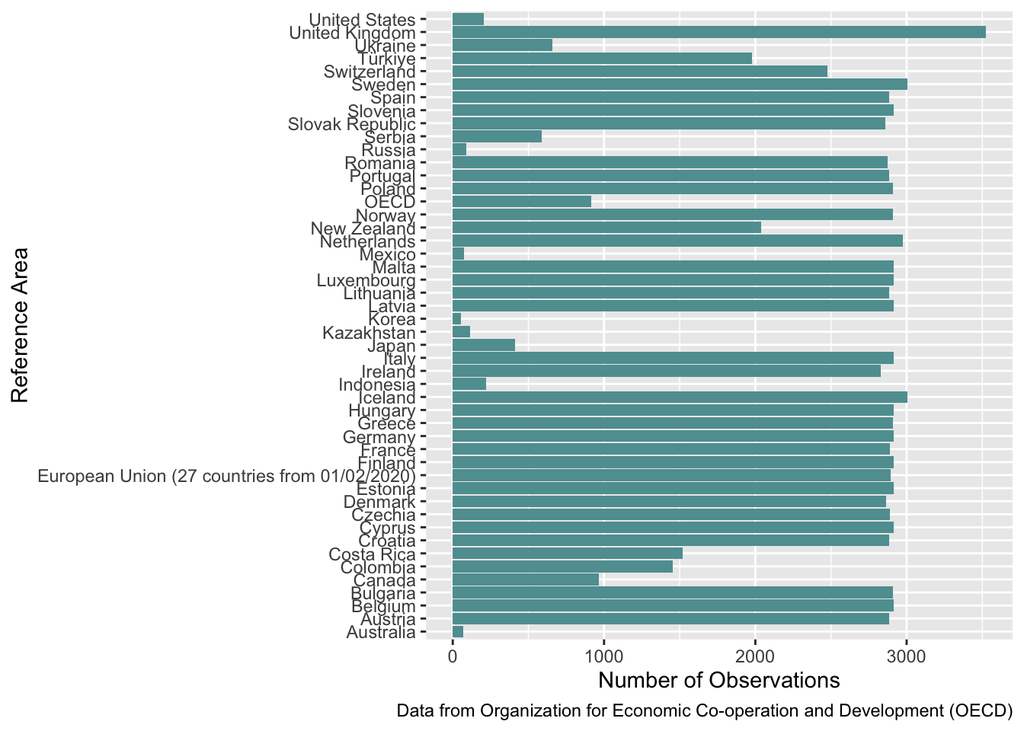

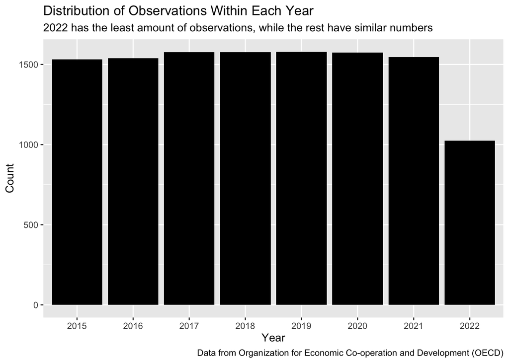

The bar chart above shows the full-year time period range of the dataset (2015-2022).

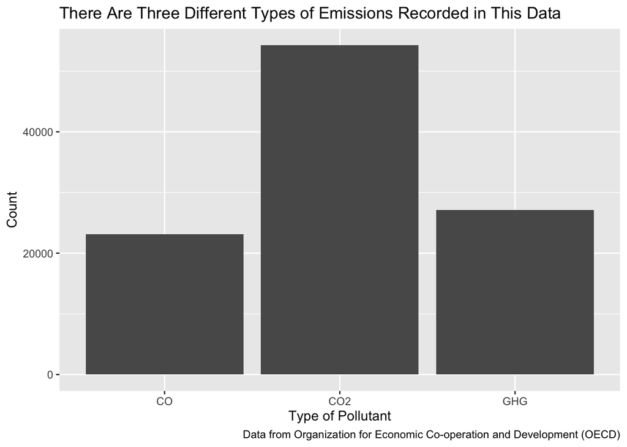

The bar graph above shows the different types of emissions recorded in this data.